# UMAP Visualization - RNA-seq

CCDL for ALSF

August 2020

# 1 Purpose of the analysis:

This notebook illustrates one way that you can use harmonized RNA-seq data from refine.bio to perform Uniform Manifold Approximation and Projection (UMAP) and plot the scores using `ggplot2`.

# 2 How to run this example

For general information about our tutorials, and for the basic software packages you will need; see our [‘Getting Started’ section](https://alexslemonade.github.io/refinebio-examples/01-getting-started/getting-started.html#how-this-tutorial-is-structured). We recommend taking a look at our [Resources for Learning R](https://alexslemonade.github.io/refinebio-examples/01-getting-started/getting-started.html#resources-for-learning-r) if you have not written code in R before.

## 2.1 Obtain the `.Rmd` file of this analysis

To run this example yourself, [download the `.Rmd` for this analysis by clicking this link](https://alexslemonade.github.io/refinebio-examples/03-rnaseq/dimension_reduction_rnaseq_02_umap.Rmd).

You can open this `.Rmd` file in RStudio and follow the rest of these steps from there (See our [section about getting started with R notebooks](https://alexslemonade.github.io/refinebio-examples/01-getting-started/getting-started.html#how-to-get-and-use-rmds) if you are unfamiliar with `.Rmd` files). Clicking this link will most likely send this to your downloads folder on your computer. Move this `.Rmd` file to where you would like this example and its files to be stored.

## 2.2 Set up your analysis folders

Good file organization is helpful for keeping your data analysis project on track! We have set up some code that will automatically set up a folder structure for you. Run this next chunk to set up your folders!

If you have trouble running this chunk, see our [introduction to using Rmds](https://alexslemonade.github.io/refinebio-examples/01-getting-started/getting-started.html#how-to-get-and-use-rmds) for more resources and explanations.

```r
# Define the file path to the data directory
data_dir <- file.path("data", "SRP133573") # Replace with path to desired data directory

# Create the data folder if it doesn't exist
if (!dir.exists(data_dir)) {
  dir.create(data_dir)
}

# Define the file path to the plots directory
plots_dir <- "plots" # Can replace with path to desired output plots directory

# Create the plots folder if it doesn't exist
if (!dir.exists(plots_dir)) {
  dir.create(plots_dir)
}

# Define the file path to the results directory
results_dir <- "results" # Can replace with path to desired output results directory

# Create the results folder if it doesn't exist
if (!dir.exists(results_dir)) {
  dir.create(results_dir)
}
```

In the same place you put this `.Rmd` file, you should now have three new empty folders called `data`, `plots`, and `results`!

## 2.3 Obtain the dataset from refine.bio

For general information about downloading data for these examples, see our [‘Getting Started’ section](https://alexslemonade.github.io/refinebio-examples/01-getting-started/getting-started.html#how-to-get-the-data).

Go to this [dataset’s page on refine.bio](https://www.refine.bio/experiments/SRP133573).

Click the “Download Now” button on the right side of this screen.

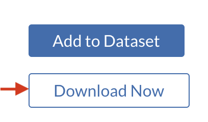

Fill out the pop up window with your email and our Terms and Conditions:

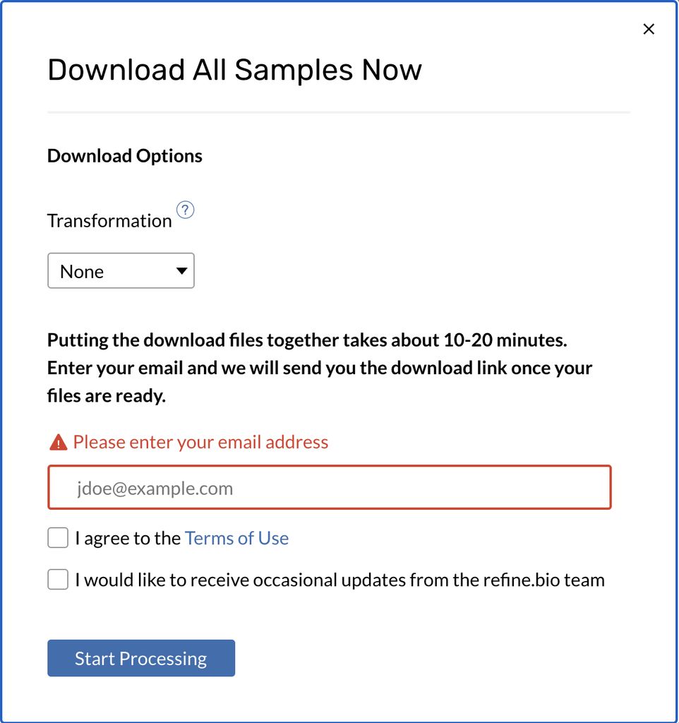

We are going to use non-quantile normalized data for this analysis. To get this data, you will need to check the box that says “Skip quantile normalization for RNA-seq samples”. Note that this option will only be available for RNA-seq datasets.

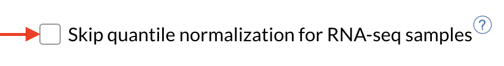

It may take a few minutes for the dataset to process. You will get an email when it is ready.

## 2.4 About the dataset we are using for this example

For this example analysis, we will use this [prostate cancer dataset](https://www.refine.bio/experiments/SRP133573).

The data that we downloaded from refine.bio for this analysis has 175 RNA-seq samples obtained from 20 patients with prostate cancer. Patients underwent androgen deprivation therapy (ADT) and RNA-seq samples include pre-ADT biopsies and post-ADT prostatectomy specimens.

## 2.5 Place the dataset in your new `data/` folder

Refine.bio will send you a download button in the email when it is ready. Follow the prompt to download a zip file that has a name with a series of letters and numbers and ends in `.zip`. Double clicking should unzip this for you and create a folder of the same name.

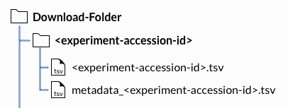

For more details on the contents of this folder see [these docs on refine.bio](http://docs.refine.bio/en/latest/main_text.html#rna-seq-sample-compendium-download-folder).

The `<experiment_accession_id>` folder has the data and metadata TSV files you will need for this example analysis. Experiment accession ids usually look something like `GSE1235` or `SRP12345`.

Copy and paste the `SRP133573` folder into your newly created `data/` folder.

## 2.6 Check out our file structure!

Your new analysis folder should contain:

- The example analysis Rmd you downloaded
- A folder called “data” which contains:
  - The `SRP133573` folder which contains:
    - The gene expression
    - The metadata TSV

Your example analysis folder should now look something like this (except with respective experiment accession id and analysis notebook name you are using):

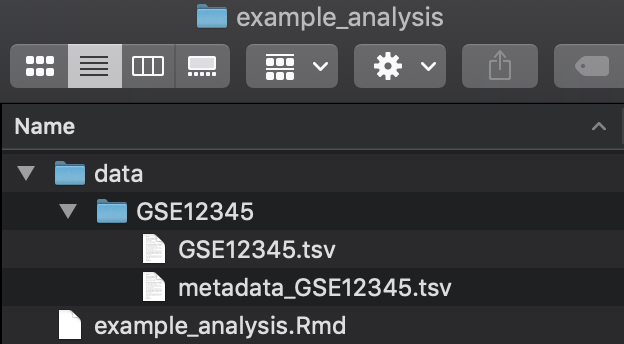

In order for our example here to run without a hitch, we need these files to be in these locations so we’ve constructed a test to check before we get started with the analysis. Run this chunk to double check that your files are in the right place.

```r
# Check if the gene expression matrix file is in the data directory stored as `data_dir`
file.exists(file.path(data_dir, "SRP133573.tsv"))
```

```
## [1] TRUE
```

```r
# Check if the metadata file is in the data directory stored as `data_dir`
file.exists(file.path(data_dir, "metadata_SRP133573.tsv"))
```

```
## [1] TRUE
```

If the chunk above printed out `FALSE` to either of those tests, you won’t be able to run this analysis *as is* until those files are in the appropriate place.

If the concept of a “file path” is unfamiliar to you; we recommend taking a look at our [section about file paths](https://alexslemonade.github.io/refinebio-examples/01-getting-started/getting-started.html#an-important-note-about-file-paths-and-Rmds).

# 3 Using a different refine.bio dataset with this analysis?

If you’d like to adapt an example analysis to use a different dataset from [refine.bio](https://www.refine.bio/), we recommend placing the files in the `data/` directory you created and changing the filenames and paths in the notebook to match these files (we’ve put comments to signify where you would need to change the code). We suggest saving plots to the `plots/` and `results/` directories, respectively, as these are automatically created by the notebook. From here you can customize this analysis example to fit your own scientific questions and preferences.

# 4 UMAP Visualization - RNA-seq

## 4.1 Install libraries

See our getting started with [package installation](https://alexslemonade.github.io/refinebio-examples/01-getting-started/getting-started.html#what-you-need-to-install) for a list of the other software you will need, as well as more tips and resources.

```r
if (!("DESeq2" %in% installed.packages())) {
  # Install DESeq2
  BiocManager::install("DESeq2", update = FALSE)
}

if (!("umap" %in% installed.packages())) {
  # Install umap package
  BiocManager::install("umap", update = FALSE)
}
```

Attach the `DESeq2`, `umap`, and `ggplot2` libraries:

```r
# Attach the `DESeq2` library
library(DESeq2)
```

```r
# Attach the `umap` library
library(umap)

# Attach the `ggplot2` library for plotting
library(ggplot2)

# We will need this so we can use the pipe: %>%
library(magrittr)

# Set the seed so our results are reproducible:
set.seed(12345)
```

## 4.2 Import and set up data

Data downloaded from refine.bio include a metadata tab separated values (TSV) file and a data TSV file. This chunk of code will read the both TSV files and add them as data frames to your environment.

```r
# Read in metadata TSV file
metadata <- readr::read_tsv(file.path(
  data_dir, # Replace with path to your metadata file
  "metadata_SRP133573.tsv" # Replace with the name of your metadata file
))
# Read in data TSV file
df <- readr::read_tsv(file.path(
  data_dir, # Replace with path to your data file
  "SRP133573.tsv" # Replace with the name of your data file
)) %>%
  # Here we are going to store the gene IDs as rownames so that we can have a numeric matrix to perform calculations on later
  tibble::column_to_rownames("Gene")
```

Let’s ensure that the metadata and data are in the same sample order.

```r
# Make the data in the order of the metadata
df <- df %>% dplyr::select(metadata$refinebio_accession_code)

# Check if this is in the same order
all.equal(colnames(df), metadata$refinebio_accession_code)
```

```
## [1] TRUE
```

Now we are going to use a combination of functions from the `DESeq2`, `umap`, and `ggplot2` packages to perform and visualize the results of the Uniform Manifold Approximation and Projection (UMAP) dimension reduction technique on our pre-ADT and post-ADT samples.

## 4.3 Prepare data for `DESeq2`

We need to make sure all of the values in our data are converted to integers as required by a `DESeq2` function we will use later.

```r
# The `DESeqDataSetFromMatrix()` function needs the values to be converted to integers
df <- df %>%
  # Mutate numeric variables to be integers
  dplyr::mutate_if(is.numeric, round)
```

## 4.4 Prepare metadata for `DESEq2`

We need to make sure all of the metadata column variables, that we would like to use to annotate our plot, are converted into factors.

```r
# We need to also format the variables from the metadata, that we will be using for annotation of the UMAP plot, into factors
metadata <- metadata %>%
  dplyr::select(
    refinebio_accession_code,
    refinebio_treatment,
    refinebio_disease
  ) %>% # The metadata has many variables, we want to select only those that we will need for plotting later
  dplyr::mutate(
    refinebio_treatment = as.factor(refinebio_treatment),
    refinebio_disease = as.factor(refinebio_disease)
  ) # Now let's make the annotation variable factors
```

## 4.5 Create a DESeqDataset

We will be using the `DESeq2` package for normalization, which requires us to format our data into a `DESeqDataSet` object. We turn the data frame (or matrix) into a `DESeqDataSet` object and specify which variable labels our experimental groups using the [`design` argument](http://bioconductor.org/packages/devel/bioc/vignettes/DESeq2/inst/doc/DESeq2.html#multi-factor-designs) (Love *et al.* 2014). In this chunk of code, we will not provide a specific model to the `design` argument because we are not performing a differential expression analysis.

```r
# Create a `DESeqDataSet` object
dds <- DESeqDataSetFromMatrix(
  countData = df, # This is the data frame with the counts values for all replicates in our dataset
  colData = metadata, # This is the data frame with the annotation data for the replicates in the counts data frame
  design = ~1 # Here we are not specifying a model -- Replace with an appropriate design variable for your analysis
)
```

## 4.6 Define a minimum counts cutoff

We want to filter out the genes that have not been expressed or that have low expression counts because we want to remove any possible noise from our data before we normalize the data and create our plot. We are going to do some pre-filtering to keep only genes with 10 or more reads total. Note that rows represent gene data and the columns represent sample data in our dataset.

```r
# Define a minimum counts cutoff and filter `DESeqDataSet` object to include
# only rows that have counts above the cutoff
genes_to_keep <- rowSums(counts(dds)) >= 10
dds <- dds[genes_to_keep, ]
```

## 4.7 Perform DESeq2 normalization

```r
# Normalize the data in the `DESeqDataSet` object using the `vst()` function from the `DESEq2` R package
dds_norm <- vst(dds)
```

## 4.8 Perform UMAP

In this code chunk, we are going to extract the normalized counts data from the `DESeqDataSet` object and perform UMAP on the normalized data using `umap()` from the `umap` package.

```r
# First we are going to retrieve the normalized data from the `DESeqDataSet` object using the `assay()` function
normalized_counts <- assay(dds_norm) %>%
  t() # We need to transpose this data in preparation for the `umap()` function

# Now let's tell R to perform UMAP on the normalized data
umap_results <- umap::umap(normalized_counts)
```

## 4.9 Prepare data frame for plotting

Now that we have the results from UMAP, we need to extract the counts data from the `umap_results` object and merge the variables from the metadata that we will use for annotating our plot.

```r
# We need to tell R to create a data frame with the umap counts and annotation data in preparation for plotting with `ggplot2`
umap_plot_df <- data.frame(umap_results$layout) %>%
  tibble::rownames_to_column("refinebio_accession_code") %>% # Let's get the rownames into a column so we can merge the annotation data
  dplyr::inner_join(metadata, by = "refinebio_accession_code") # Let's merge the annotation data using the `refinebio_accession_code` column
```

## 4.10 Create UMAP plot

In this chunk, we are are going to use the `ggplot` function to plot our normalized UMAP scores.

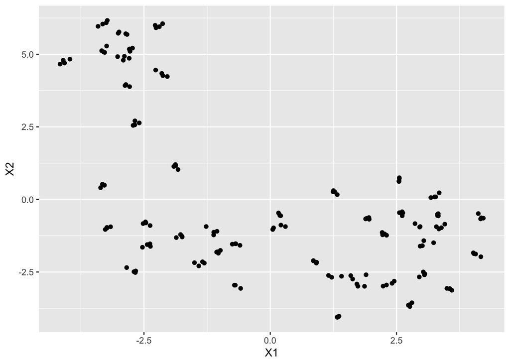

```r
# Plot using `ggplot()` function
ggplot(umap_plot_df, aes(x = X1, y = X2)) +
  geom_point() # This tells R that we want a scatterplot
```

Now we are going to add a variable to our plot for annotation.

In this code chunk, the variable `refinebio_treatment` is given to the `ggplot()` function as part of the goal of the experiment is to analyze the differential responses to androgen deprivation therapy (ADT).

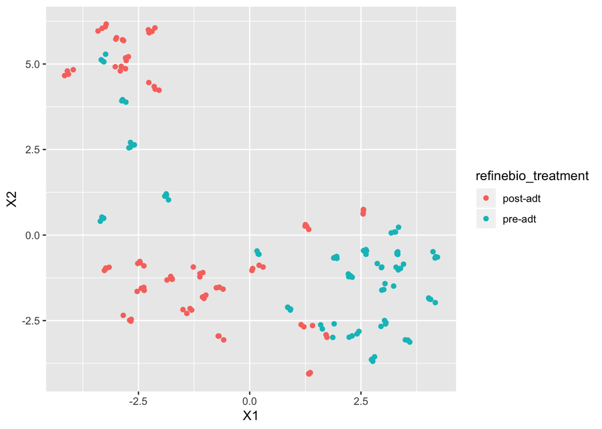

```r
# Plot using `ggplot()` function
ggplot(
  umap_plot_df,
  aes(
    x = X1,
    y = X2,
    color = refinebio_treatment # Here we are giving `refinebio_treatment` to the color argument
  )
) +
  geom_point() # This tells R that we want a scatterplot
```

In the next code chunk, the variables `refinebio_treatment` and `refinebio_disease` are given to `ggplot()` due to the hypothesis of the experiment that states that differences in the tumor transcriptional platforms may also show differences in response to the androgen deprivation therapy (ADT) as noted in the associated [paper](https://www.ncbi.nlm.nih.gov/pmc/articles/PMC6210624/) (Sharma *et al.* 2018).

Now let’s plot using `ggplot2` functionality.

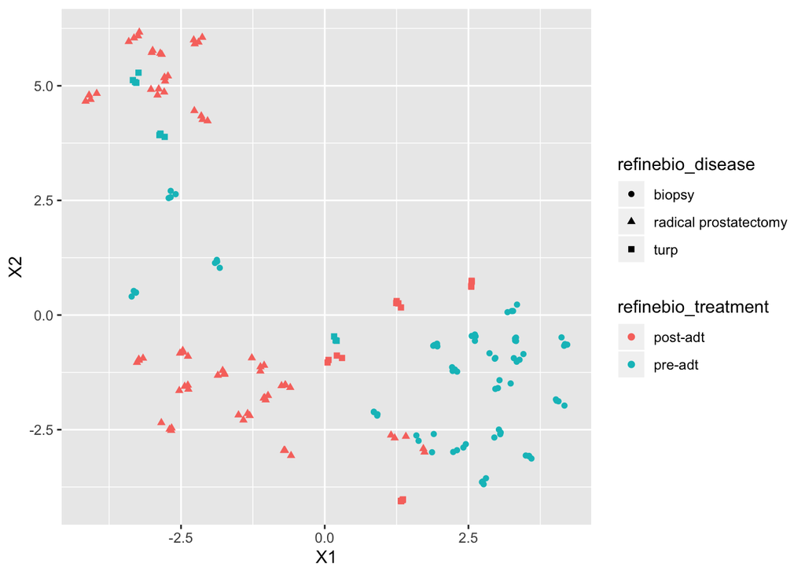

```r
# Plot using `ggplot()` function
final_annotated_umap_plot <- ggplot(
  umap_plot_df,
  aes(
    x = X1,
    y = X2,
    color = refinebio_treatment,
    # Here we are giving `refinebio_treatment` to the color argument
    shape = refinebio_disease # Here we are giving `refinebio_disease` to the shape argument
  )
) +
  geom_point() # This tells R that we want a scatterplot

# Display the plot that we saved above
final_annotated_umap_plot
```

## 4.11 Save annotated UMAP plot as a PNG

You can easily switch this to save to a JPEG or TIFF by changing the file name within the `ggsave()` function to the respective file suffix.

```r
# Save plot using `ggsave()` function
ggsave(file.path(plots_dir, "SRP133573_umap_plot.png"), # Replace with name relevant your plotted data
  plot = final_annotated_umap_plot
)
```

# 5 Resources for further learning

- [Guidelines on choosing dimension reduction methods](https://journals.plos.org/ploscompbiol/article/file?id=10.1371/journal.pcbi.1006907&type=printable) (Nguyen and Holmes 2019)
- [A nice explanation and comparison of many different dimensionality reduction techniques that you may encounter](https://rpubs.com/Saskia/520216) (Freytag 2019)

# 6 Print session info:

At the end of every analysis, before saving your notebook, we recommend printing out your session info. This helps make your code more reproducible by recording what versions of softwares and packages you used to run this.

[session information not shown]

Freytag S., 2019 Workshop: Dimension reduction with r

Konopka T., 2020 *Uniform manifold approximation and projection*.

Love M. I., W. Huber, and S. Anders, 2014 Moderated estimation of fold change and dispersion for rna-seq data with deseq2. Genome Biology 15. https://doi.org/10.1186/s13059-014-0550-8

Nguyen L. H., and S. Holmes, 2019 Ten quick tips for effective dimensionality reduction. PLOS Computational Biology 15. https://doi.org/10.1371/journal.pcbi.1006907

Prabhakaran S., *The complete ggplot2 tutorial*.

Sharma N. V., K. L. Pellegrini, V. Ouellet, F. O. Giuste, and S. Ramalingam *et al.*, 2018 Identification of the transcription factor relationships associated with androgen deprivation therapy response and metastatic progression in prostate cancer. Cancers 10. https://doi.org/10.3390/cancers10100379